# Predicting Appliance Energy Consumption In Households

Develop a robust machine learning model to accurately predict appliance energy consumption in households. By utilizing this model, the company aims to improve energy efficiency recommendations, optimize power grid management, and help customers reduce their energy costs.

**Project Benefits:**

1. Energy Optimization: The model will help identify factors influencing appliance energy consumption, allowing for more targeted energy-saving strategies.
2. Cost Reduction: By predicting energy usage accurately, customers can better manage their consumption and reduce energy bills.
3. Grid Management: Understanding household energy patterns can assist in better power grid management and load balancing.

**Output:**

1. A documented machine learning model specifically designed for predicting appliance energy consumption.
2. Comprehensive data visualizations illustrating relationships between various environmental factors and energy usage.
3. A comparative analysis of different machine learning algorithms for this prediction task.

# **DATA SETUP AND LOADING**

Import all necessary libraries and load the dataset

```python
#ENERGY CONSUMPTION PREDICTION
#ARIES DIMAANO
#dimaanoac@gmail.com

#Import Libraries
!pip install scikit-learn==1.5.0 #to avoid xgboost error
import pandas as pd
import numpy as np
import matplotlib.pyplot as plt
import seaborn as sns
import xgboost as xgb
import joblib
from sklearn.preprocessing import StandardScaler
from sklearn.preprocessing import PolynomialFeatures
from sklearn.model_selection import train_test_split, GridSearchCV
from sklearn.linear_model import LinearRegression
from sklearn.ensemble import RandomForestRegressor, GradientBoostingRegressor, StackingRegressor
from xgboost import XGBRegressor
from sklearn.metrics import mean_squared_error, r2_score
from scipy import stats
from statsmodels.graphics.tsaplots import plot_acf
import warnings
warnings.filterwarnings("ignore")

from google.colab import drive
from google.colab import files
drive.mount('/content/drive')
import os
```

# Exploratory Data Analysis

Perform an initial examination of the data to understand its structure, data types, and basic statistics

```python
#Load Dataset
os.getcwd()
os.chdir('/content/drive/MyDrive/DATA SCIENCE PROJECT/Predicting Appliance Energy Consumption In Households')
df = pd.read_csv('energydata_complete.csv')
```

```python
df.head()
```

|  | date | Appliances | lights | T1 | RH_1 | T2 | RH_2 | T3 | RH_3 | T4 | ... | T9 | RH_9 | T_out | Press_mm_hg | RH_out | Windspeed | Visibility | Tdewpoint | rv1 | rv2 |
| --- | --- | --- | --- | --- | --- | --- | --- | --- | --- | --- | --- | --- | --- | --- | --- | --- | --- | --- | --- | --- | --- |
| 0 | 11-01-2016 17:00 | 60 | 30 | 19.89 | 47.596667 | 19.2 | 44.790000 | 19.79 | 44.730000 | 19.000000 | ... | 17.033333 | 45.53 | 6.60 | 733.5 | 92.0 | 7.000000 | 63.000000 | 5.3 | 13.275433 | 13.275433 |
| 1 | 11-01-2016 17:10 | 60 | 30 | 19.89 | 46.693333 | 19.2 | 44.722500 | 19.79 | 44.790000 | 19.000000 | ... | 17.066667 | 45.56 | 6.48 | 733.6 | 92.0 | 6.666667 | 59.166667 | 5.2 | 18.606195 | 18.606195 |
| 2 | 11-01-2016 17:20 | 50 | 30 | 19.89 | 46.300000 | 19.2 | 44.626667 | 19.79 | 44.933333 | 18.926667 | ... | 17.000000 | 45.50 | 6.37 | 733.7 | 92.0 | 6.333333 | 55.333333 | 5.1 | 28.642668 | 28.642668 |
| 3 | 11-01-2016 17:30 | 50 | 40 | 19.89 | 46.066667 | 19.2 | 44.590000 | 19.79 | 45.000000 | 18.890000 | ... | 17.000000 | 45.40 | 6.25 | 733.8 | 92.0 | 6.000000 | 51.500000 | 5.0 | 45.410390 | 45.410390 |
| 4 | 11-01-2016 17:40 | 60 | 40 | 19.89 | 46.333333 | 19.2 | 44.530000 | 19.79 | 45.000000 | 18.890000 | ... | 17.000000 | 45.40 | 6.13 | 733.9 | 92.0 | 5.666667 | 47.666667 | 4.9 | 10.084097 | 10.084097 |

5 rows × 29 columns

```python
df.info()
```

```
<class 'pandas.core.frame.DataFrame'>
RangeIndex: 19735 entries, 0 to 19734
Data columns (total 29 columns):
 #   Column       Non-Null Count  Dtype
---  ------       --------------  -----
 0   date         19735 non-null  object
 1   Appliances   19735 non-null  int64
 2   lights       19735 non-null  int64
 3   T1           19735 non-null  float64
 4   RH_1         19735 non-null  float64
 5   T2           19735 non-null  float64
 6   RH_2         19735 non-null  float64
 7   T3           19735 non-null  float64
 8   RH_3         19735 non-null  float64
 9   T4           19735 non-null  float64
```

[output cut: 21 more lines]

```python
df.describe()
```

|  | Appliances | lights | T1 | RH_1 | T2 | RH_2 | T3 | RH_3 | T4 | RH_4 | ... | T9 | RH_9 | T_out | Press_mm_hg | RH_out | Windspeed | Visibility | Tdewpoint | rv1 | rv2 |
| --- | --- | --- | --- | --- | --- | --- | --- | --- | --- | --- | --- | --- | --- | --- | --- | --- | --- | --- | --- | --- | --- |
| count | 19735.000000 | 19735.000000 | 19735.000000 | 19735.000000 | 19735.000000 | 19735.000000 | 19735.000000 | 19735.000000 | 19735.000000 | 19735.000000 | ... | 19735.000000 | 19735.000000 | 19735.000000 | 19735.000000 | 19735.000000 | 19735.000000 | 19735.000000 | 19735.000000 | 19735.000000 | 19735.000000 |
| mean | 97.694958 | 3.801875 | 21.686571 | 40.259739 | 20.341219 | 40.420420 | 22.267611 | 39.242500 | 20.855335 | 39.026904 | ... | 19.485828 | 41.552401 | 7.412580 | 755.522602 | 79.750418 | 4.039752 | 38.330834 | 3.760995 | 24.988033 | 24.988033 |
| std | 102.524891 | 7.935988 | 1.606066 | 3.979299 | 2.192974 | 4.069813 | 2.006111 | 3.254576 | 2.042884 | 4.341321 | ... | 2.014712 | 4.151497 | 5.318464 | 7.399441 | 14.901088 | 2.451221 | 11.794719 | 4.195248 | 14.496634 | 14.496634 |
| min | 10.000000 | 0.000000 | 16.790000 | 27.023333 | 16.100000 | 20.463333 | 17.200000 | 28.766667 | 15.100000 | 27.660000 | ... | 14.890000 | 29.166667 | -5.000000 | 729.300000 | 24.000000 | 0.000000 | 1.000000 | -6.600000 | 0.005322 | 0.005322 |
| 25% | 50.000000 | 0.000000 | 20.760000 | 37.333333 | 18.790000 | 37.900000 | 20.790000 | 36.900000 | 19.530000 | 35.530000 | ... | 18.000000 | 38.500000 | 3.670000 | 750.933333 | 70.333333 | 2.000000 | 29.000000 | 0.900000 | 12.497889 | 12.497889 |
| 50% | 60.000000 | 0.000000 | 21.600000 | 39.656667 | 20.000000 | 40.500000 | 22.100000 | 38.530000 | 20.666667 | 38.400000 | ... | 19.390000 | 40.900000 | 6.920000 | 756.100000 | 83.666667 | 3.666667 | 40.000000 | 3.430000 | 24.897653 | 24.897653 |
| 75% | 100.000000 | 0.000000 | 22.600000 | 43.066667 | 21.500000 | 43.260000 | 23.290000 | 41.760000 | 22.100000 | 42.156667 | ... | 20.600000 | 44.338095 | 10.400000 | 760.933333 | 91.666667 | 5.500000 | 40.000000 | 6.570000 | 37.583769 | 37.583769 |
| max | 1080.000000 | 70.000000 | 26.260000 | 63.360000 | 29.856667 | 56.026667 | 29.236000 | 50.163333 | 26.200000 | 51.090000 | ... | 24.500000 | 53.326667 | 26.100000 | 772.300000 | 100.000000 | 14.000000 | 66.000000 | 15.500000 | 49.996530 | 49.996530 |

8 rows × 28 columns

```python
df.isna().sum() #Check for missing values
```

|  | 0 |
| --- | --- |
| date | 0 |
| Appliances | 0 |
| lights | 0 |
| T1 | 0 |
| RH_1 | 0 |
| T2 | 0 |
| RH_2 | 0 |
| T3 | 0 |
| RH_3 | 0 |
| T4 | 0 |
| RH_4 | 0 |
| T5 | 0 |
| RH_5 | 0 |
| T6 | 0 |
| RH_6 | 0 |
| T7 | 0 |
| RH_7 | 0 |
| T8 | 0 |
| RH_8 | 0 |
| T9 | 0 |
| RH_9 | 0 |
| T_out | 0 |
| Press_mm_hg | 0 |
| RH_out | 0 |
| Windspeed | 0 |
| Visibility | 0 |
| Tdewpoint | 0 |
| rv1 | 0 |
| rv2 | 0 |

**dtype:** int64

```python
df.duplicated().sum() #Check for duplicates
```

```
0
```

```python
#Convert the first column to datetime objects
df['date'] = pd.to_datetime(df['date'], format='%d-%m-%Y %H:%M', errors='coerce')
```

```python
df.info()
```

```
<class 'pandas.core.frame.DataFrame'>
RangeIndex: 19735 entries, 0 to 19734
Data columns (total 29 columns):
 #   Column       Non-Null Count  Dtype
---  ------       --------------  -----
 0   date         19735 non-null  datetime64[ns]
 1   Appliances   19735 non-null  int64
 2   lights       19735 non-null  int64
 3   T1           19735 non-null  float64
 4   RH_1         19735 non-null  float64
 5   T2           19735 non-null  float64
 6   RH_2         19735 non-null  float64
 7   T3           19735 non-null  float64
 8   RH_3         19735 non-null  float64
 9   T4           19735 non-null  float64
```

[output cut: 21 more lines]

```python
#Set 'date' column as the index
df = df.set_index('date')
```

```python
df.head()
```

| date | Appliances | lights | T1 | RH_1 | T2 | RH_2 | T3 | RH_3 | T4 | RH_4 | ... | T9 | RH_9 | T_out | Press_mm_hg | RH_out | Windspeed | Visibility | Tdewpoint | rv1 | rv2 |
| --- | --- | --- | --- | --- | --- | --- | --- | --- | --- | --- | --- | --- | --- | --- | --- | --- | --- | --- | --- | --- | --- |
| 2016-01-11 17:00:00 | 60 | 30 | 19.89 | 47.596667 | 19.2 | 44.790000 | 19.79 | 44.730000 | 19.000000 | 45.566667 | ... | 17.033333 | 45.53 | 6.60 | 733.5 | 92.0 | 7.000000 | 63.000000 | 5.3 | 13.275433 | 13.275433 |
| 2016-01-11 17:10:00 | 60 | 30 | 19.89 | 46.693333 | 19.2 | 44.722500 | 19.79 | 44.790000 | 19.000000 | 45.992500 | ... | 17.066667 | 45.56 | 6.48 | 733.6 | 92.0 | 6.666667 | 59.166667 | 5.2 | 18.606195 | 18.606195 |
| 2016-01-11 17:20:00 | 50 | 30 | 19.89 | 46.300000 | 19.2 | 44.626667 | 19.79 | 44.933333 | 18.926667 | 45.890000 | ... | 17.000000 | 45.50 | 6.37 | 733.7 | 92.0 | 6.333333 | 55.333333 | 5.1 | 28.642668 | 28.642668 |
| 2016-01-11 17:30:00 | 50 | 40 | 19.89 | 46.066667 | 19.2 | 44.590000 | 19.79 | 45.000000 | 18.890000 | 45.723333 | ... | 17.000000 | 45.40 | 6.25 | 733.8 | 92.0 | 6.000000 | 51.500000 | 5.0 | 45.410390 | 45.410390 |
| 2016-01-11 17:40:00 | 60 | 40 | 19.89 | 46.333333 | 19.2 | 44.530000 | 19.79 | 45.000000 | 18.890000 | 45.530000 | ... | 17.000000 | 45.40 | 6.13 | 733.9 | 92.0 | 5.666667 | 47.666667 | 4.9 | 10.084097 | 10.084097 |

5 rows × 28 columns

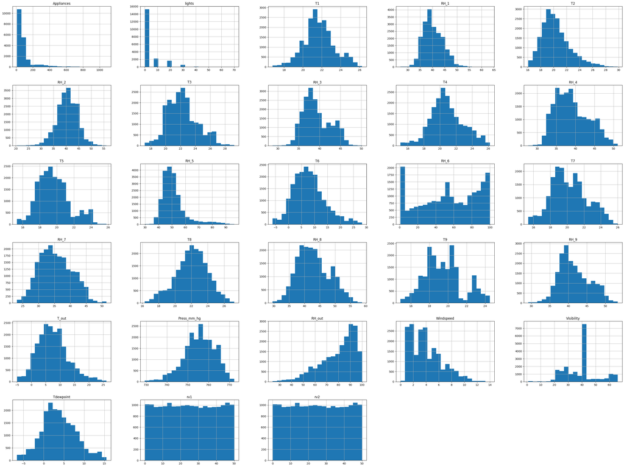

```python
#Explore the data with Histogram
df.hist(bins=20, figsize=(40,30))
plt.show()
```

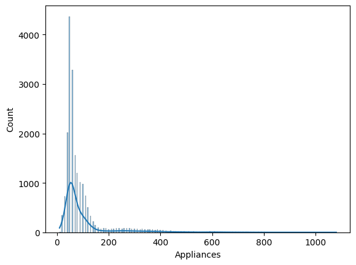

```python
#Explore the target data with Histogram
sns.histplot(df['Appliances'], kde=True)
plt.show()
```

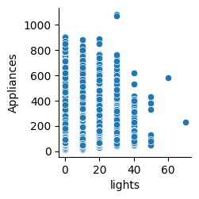

```python
#Pairplot target features vs lights
plt.figure(figsize=(12,7))
sns.pairplot(df, x_vars=['lights'], y_vars=['Appliances'])
plt.show()
```

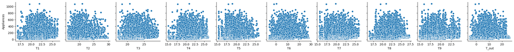

```python
#Pairplot target features vs Temperature features
plt.figure(figsize=(12,7))
sns.pairplot(df, x_vars=[ 'T1', 'T2', 'T3', 'T4', 'T5', 'T6', 'T7', 'T8', 'T9', 'T_out'], y_vars=['Appliances'])
plt.show()
```

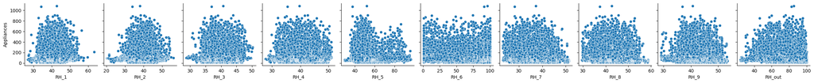

```python
#Pairplot target features vs Humidity
plt.figure(figsize=(12,7))
sns.pairplot(df, x_vars=[ 'RH_1', 'RH_2', 'RH_3', 'RH_4', 'RH_5', 'RH_6', 'RH_7', 'RH_8', 'RH_9', 'RH_out'], y_vars=['Appliances'])
plt.show()
```

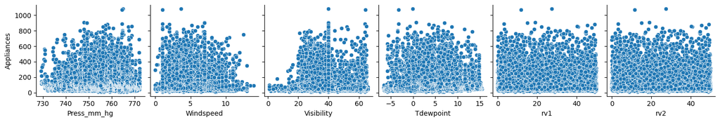

```python
#Pairplot target features vs other features
plt.figure(figsize=(12,7))
sns.pairplot(df, x_vars=['Press_mm_hg', 'Windspeed', 'Visibility', 'Tdewpoint', 'rv1', 'rv2'], y_vars=['Appliances'])
plt.show()
```

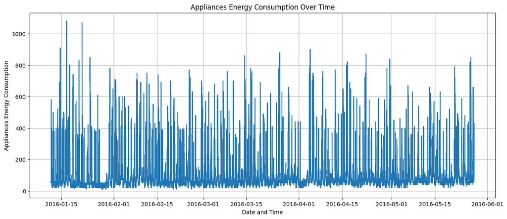

```python
#Plot time series of 'Appliances' energy consumption
plt.figure(figsize=(15, 6))
plt.plot(df.index, df['Appliances'])
plt.xlabel('Date and Time')
plt.ylabel('Appliances Energy Consumption')
plt.title('Appliances Energy Consumption Over Time')
plt.grid(True)
plt.show()
```

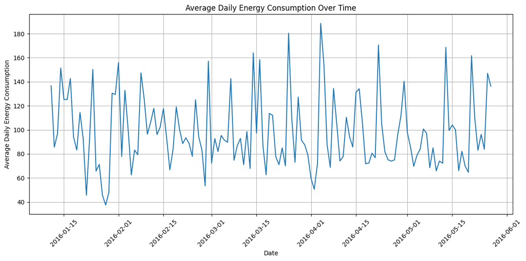

```python
#Calculate daily average energy consumption
daily_avg_con = df['Appliances'].resample('D').mean()

#Create the line graph for daily average energy consumption
plt.figure(figsize=(12, 6))
plt.plot(daily_avg_con.index, daily_avg_con.values)
plt.xlabel('Date')
plt.ylabel('Average Daily Energy Consumption')
plt.title('Average Daily Energy Consumption Over Time')
plt.grid(True)
plt.xticks(rotation=45)
plt.tight_layout()
plt.show()
```

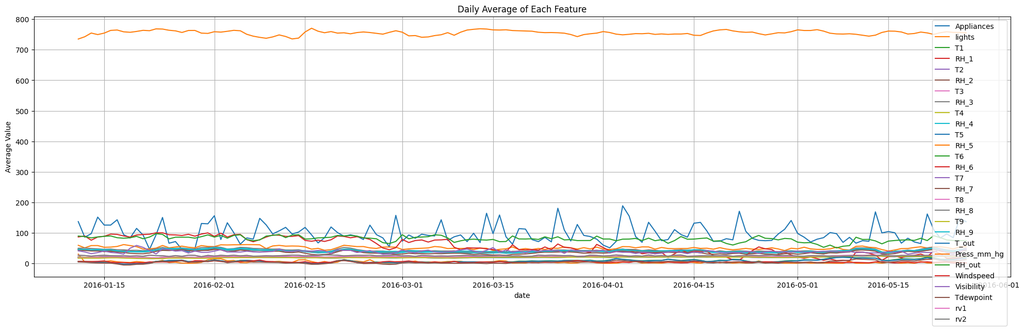

```python
#Calculate daily average energy consumption
daily_avg = df.resample('D').mean()

#Create the histogram
plt.figure(figsize=(20, 6))

for column in daily_avg.columns:
    plt.plot(daily_avg.index,daily_avg[column].values, label=column)

plt.xlabel('date')
plt.ylabel('Average Value')
plt.title('Daily Average of Each Feature')
plt.grid(True)
plt.tight_layout()
plt.legend()
plt.show()
```

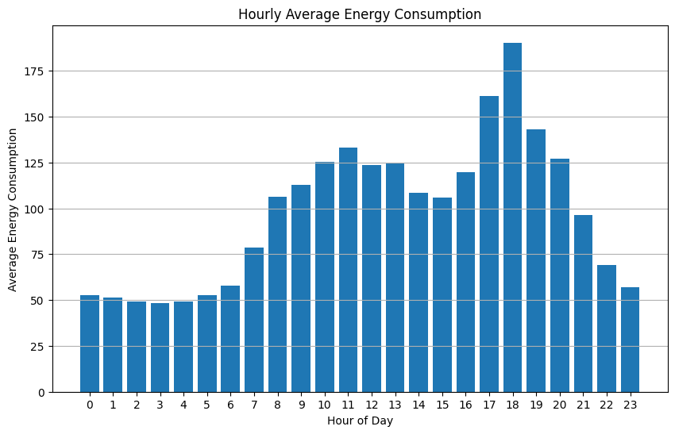

```python
#Group data by hour and calculate the mean energy consumption for each hour
hourly_avg = df['Appliances'].groupby(df.index.hour).mean()

#Create the histogram
plt.figure(figsize=(10, 6))
plt.bar(hourly_avg.index, hourly_avg.values)
plt.xlabel('Hour of Day')
plt.ylabel('Average Energy Consumption')
plt.title('Hourly Average Energy Consumption')
plt.xticks(range(24))  # Ensure all 24 hours are displayed on the x-axis
plt.grid(axis='y')
plt.show()
```

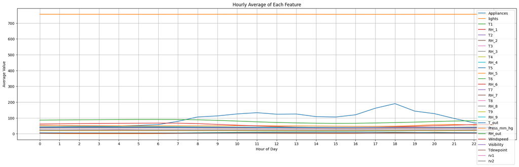

```python
#Compare the other features to the average hourly energy consumption
#Group data by hour and calculate the mean for each feature
hourly_avg = df.groupby(df.index.hour).mean()

#Create the histogram
plt.figure(figsize=(20, 6))  # Adjust figure size as needed

for column in hourly_avg.columns:
    plt.plot(hourly_avg.index, hourly_avg[column], label=column)

plt.xlabel('Hour of Day')
plt.ylabel('Average Value')
plt.title('Hourly Average of Each Feature')
plt.xticks(range(24))
plt.grid(True)
plt.tight_layout()
plt.legend()
plt.show()
```

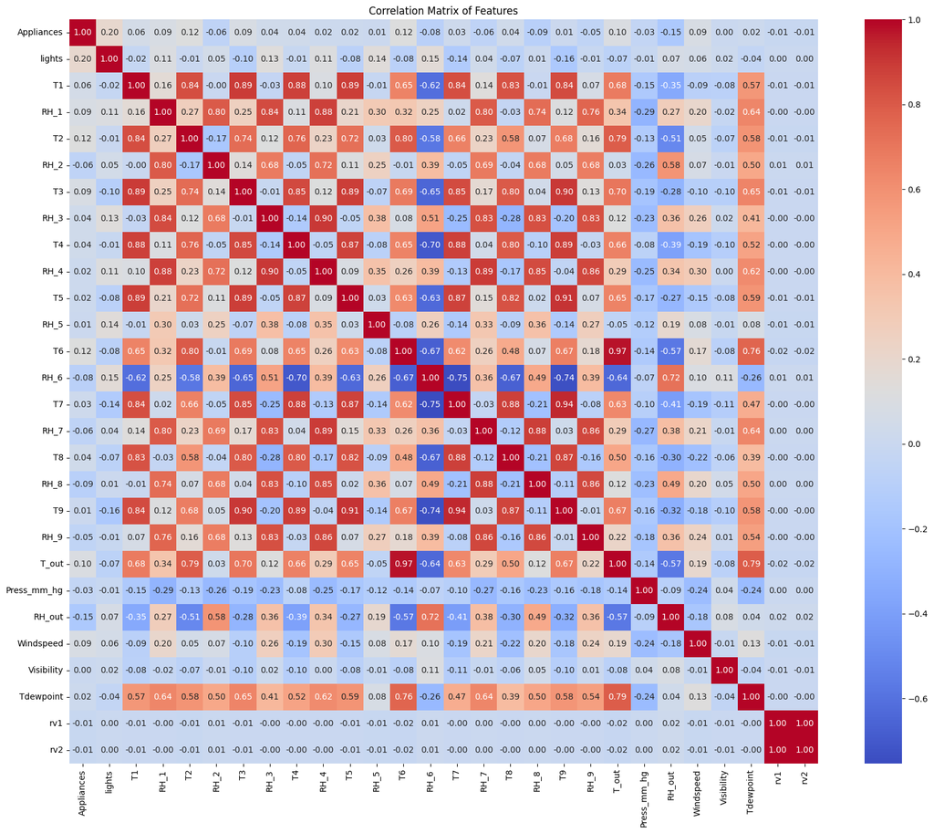

```python
#Calculate the correlation matrix
corr_matrix = pd.DataFrame(df, columns=df.columns).corr()

#Plot the heatmap
plt.figure(figsize=(20, 16))
sns.heatmap(corr_matrix, annot=True, cmap='coolwarm', fmt=".2f")
plt.title('Correlation Matrix of Features')
plt.show()
```

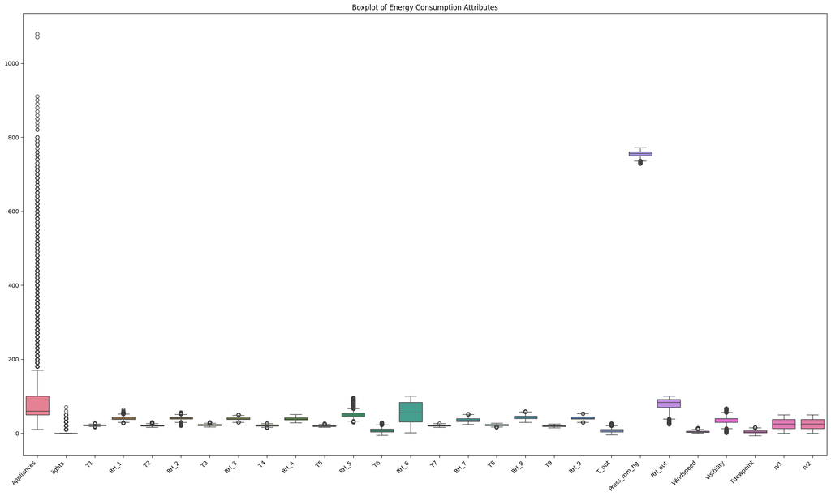

```python
#Create a boxplot for each feature
plt.figure(figsize=(20, 12))
sns.boxplot(data=df)
plt.title('Boxplot of Energy Consumption Attributes')
plt.xticks(rotation=45, ha='right')
plt.tight_layout()
plt.show()
```

# Data Preprocessing and Feature Engineering

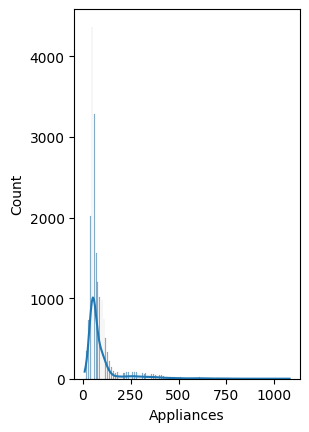

```python
#For outlier detection, Box-cox method is used
df['appliance_boxcox'], lambda_value = stats.boxcox(df['Appliances'])

plt.subplot(1,2,1)
sns.histplot(df['Appliances'], kde=True)
```

```python
#Determine Q1 and Q3
Q1 = df['Appliances'].quantile(0.25)
Q3 = df['Appliances'].quantile(0.75)
IQR = Q3 - Q1

lower_bound = Q1 - 1.5 * IQR
upper_bound = Q3 + 1.5 * IQR

print("Lower Bound:", lower_bound)
print("Upper Bound:", upper_bound)

df['is_outlier'] = (df['Appliances'] < lower_bound) | (df['Appliances'] > upper_bound)
print ("Number of detected outliers:" , df['is_outlier'].sum())
```

```
Lower Bound: -25.0
Upper Bound: 175.0
Number of detected outliers: 2138
```

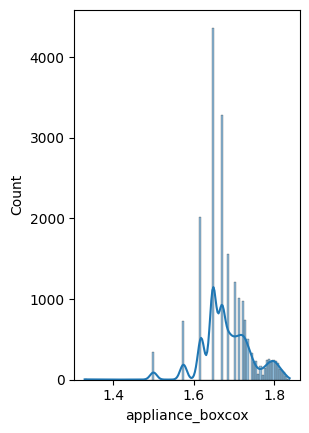

```python
#Impute detected outliers with median
median_value = df['Appliances'].median()
df.loc[df['is_outlier'], 'appliances_boxcox'] = median_value

plt.subplot(1,2,2)
sns.histplot(df['appliance_boxcox'], kde=True)
```

```python
#Extract datetime components
df['hour'] = df.index.hour
df['day'] = df.index.day
df['day_of_week'] = df.index.dayofweek
df['month'] = df.index.month
```

```python
#Get the average Temperature and Humidity inside the house with column T1-T9 and RH_1-RH_9
df['T_in_ave'] = df[['T1', 'T2', 'T3', 'T4', 'T5', 'T6', 'T7', 'T8', 'T9']].mean(axis=1)
df['RH_in_ave'] = df[['RH_1', 'RH_2', 'RH_3', 'RH_4', 'RH_5', 'RH_6', 'RH_7', 'RH_8', 'RH_9']].mean(axis=1)
df['temp-diff'] = df['T_out'] - df['T_in_ave']
df['rh-diff'] = df['RH_out'] - df['RH_in_ave']
```

```python
#Create a lag feature (previous hour's energy consumption)
df['lag_1'] = df['Appliances'].shift(1)

#Create a rolling average (mean over the past 3 hours)
df['rolling_mean_3'] = df['Appliances'].rolling(window=3).mean()

df=df.dropna()
```

```python
#Assume 'features' is a list of feature column names you plan to use
features = ['hour', 'day_of_week', 'temp-diff', 'lag_1', 'rolling_mean_3']

scaler = StandardScaler()
df[features] = scaler.fit_transform(df[features])

#Create polynomial and interaction features (degree=2 captures pairwise interactions)
poly = PolynomialFeatures(degree=2, interaction_only=True, include_bias=False)
poly_features = poly.fit_transform(df[features])
poly_feature_names = poly.get_feature_names_out(features)

#Convert to DataFrame and merge with original data
df_poly = pd.DataFrame(poly_features, columns=poly_feature_names, index=df.index)
df_poly = df_poly.drop(columns=['hour', 'day_of_week', 'temp-diff', 'lag_1', 'rolling_mean_3'])
df = pd.concat([df, df_poly], axis=1)
```

```python
#Define the target and features
target = df['Appliances']
features = df.drop('Appliances', axis=1)
```

```python
#Split the dataset (80% train, 20% test)
X_train, X_test, y_train, y_test = train_test_split(features, target, test_size=0.2, random_state=42)
```

```python
#Scale the features using StandardScaler
scaler = StandardScaler()
X_train_scaled = scaler.fit_transform(X_train)
X_test_scaled = scaler.transform(X_test)
```

# Building a Baseline Model (Linear Regression)

A simple baseline model helps set a performance benchmark.

```python
#Initialize and train a Linear Regression model
lr_model = LinearRegression()
lr_model.fit(X_train_scaled, y_train)

#Predict on the test set
y_pred_lr = lr_model.predict(X_test_scaled)

#Evaluate model performance
mse_lr = mean_squared_error(y_test, y_pred_lr)
rmse_lr = np.sqrt(mse_lr)
r2_lr = r2_score(y_test, y_pred_lr)

print("Linear Regression Performance:")
print("RMSE:", rmse_lr)
print("R2:", r2_lr)
```

```
Linear Regression Performance:
RMSE: 47.9733952597354
R2: 0.8965217057104999
```

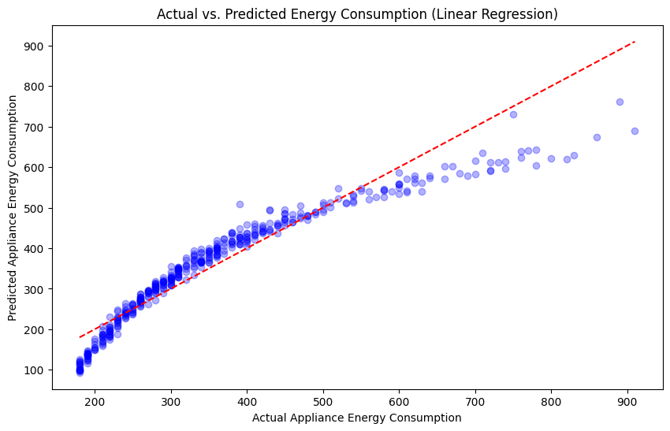

```python
plt.figure(figsize=(10, 6))
plt.scatter(y_test, y_pred_lr, alpha=0.3, color='blue')
plt.xlabel('Actual Appliance Energy Consumption')
plt.ylabel('Predicted Appliance Energy Consumption')
plt.title('Actual vs. Predicted Energy Consumption (Linear Regression)')
plt.plot([y_test.min(), y_test.max()], [y_test.min(), y_test.max()], 'r--')  # Diagonal line
plt.show()
```

# Building a More Robust Model

Tree-based ensemble models like Random Forest, XGBoost and Gradient Boost often capture non-linear relationships better than linear models.

Hyperparameter Tuning: Use GridSearchCV to search for the best hyperparameters to potentially improve performance.

# **Random Forest Regressor**

```python
#Initialize a RandomForestRegressor
rf = RandomForestRegressor(random_state=42)

#Train the model on your training data
rf.fit(X_train_scaled, y_train)

#Predict on the test set
y_pred_rf = rf.predict(X_test_scaled)
```

```
Basic Random Forest Performance:
RMSE: 6.061987043526889
R²: 0.9983477401239771
```

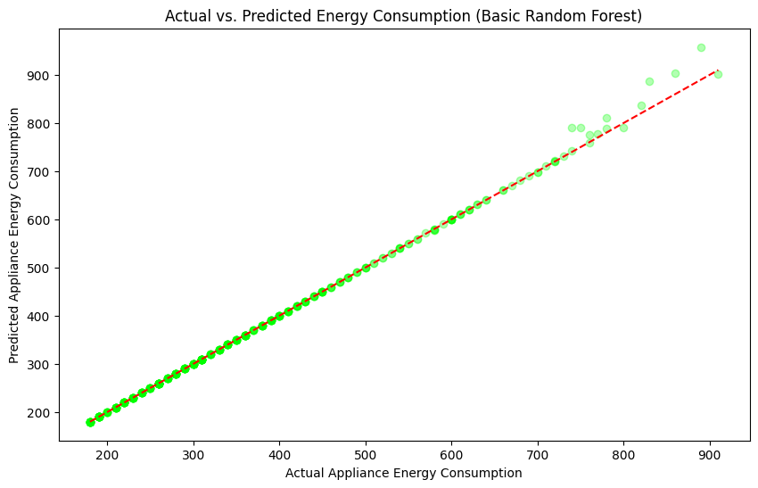

```python
#Evaluate performance
mse_rf = mean_squared_error(y_test, y_pred_rf)
rmse_rf = np.sqrt(mse_rf)
r2_rf = r2_score(y_test, y_pred_rf)

print("Basic Random Forest Performance:")
print("RMSE:", rmse_rf)
print("R²:", r2_rf)

#Plot the actual vs predicted energy consumption
plt.figure(figsize=(10, 6))
plt.scatter(y_test, y_pred_rf, alpha=0.3, color='lime')
plt.xlabel('Actual Appliance Energy Consumption')
plt.ylabel('Predicted Appliance Energy Consumption')
plt.title('Actual vs. Predicted Energy Consumption (Basic Random Forest)')
plt.plot([y_test.min(), y_test.max()], [y_test.min(), y_test.max()], 'r--')  # Diagonal line
plt.show()
```

```python
#Define a parameter grid for hyperparameter tuning
param_grid_rf = {
    'n_estimators': [100, 200, 300],
    'max_depth': [None, 10, 20, 30],
    'min_samples_split': [2, 5, 10],
    'min_samples_leaf': [1, 2, 4],
    'max_features': ['auto', 'sqrt', 'log2']
}

#Set up GridSearchCV for hyperparameter tuning
grid_search_rf = GridSearchCV(estimator=rf,
                           param_grid=param_grid_rf,
                           cv=3,
                           n_jobs=-1,
                           scoring='neg_mean_squared_error',
                           verbose=1)

#Fit GridSearchCV on the training data
grid_search_rf.fit(X_train_scaled, y_train)

#Retrieve the best estimator and parameters
print("Best parameters:", grid_search_rf.best_params_)
best_rf = grid_search_rf.best_estimator_


#Predict on the test set using the best RandomForest model
y_pred_rf_hpt = best_rf.predict(X_test_scaled)
```

```
Fitting 3 folds for each of 324 candidates, totalling 972 fits
Best parameters: {'max_depth': 20, 'max_features': 'sqrt', 'min_samples_leaf': 1, 'min_samples_split': 2, 'n_estimators': 300}
```

```
Tuned Random Forest Regressor Performance:
RMSE: 47.82839710119522
R2: 0.8971462805284025
```

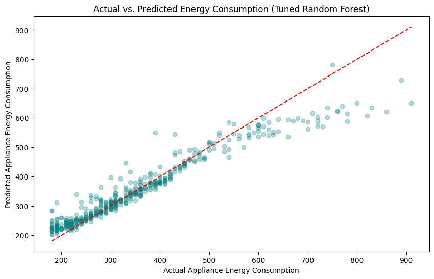

```python
#Evaluate the Random Forest model
mse_rf_hpt = mean_squared_error(y_test, y_pred_rf_hpt)
rmse_rf_hpt = np.sqrt(mse_rf_hpt)
r2_rf_hpt = r2_score(y_test, y_pred_rf_hpt)

print("\nTuned Random Forest Regressor Performance:")
print("RMSE:", rmse_rf_hpt)
print("R2:", r2_rf_hpt)

#Plot actual vs predicted energy consumption
plt.figure(figsize=(10, 6))
plt.scatter(y_test, y_pred_rf_hpt, alpha=0.3, color='teal')
plt.xlabel('Actual Appliance Energy Consumption')
plt.ylabel('Predicted Appliance Energy Consumption')
plt.title('Actual vs. Predicted Energy Consumption (Tuned Random Forest)')
plt.plot([y_test.min(), y_test.max()], [y_test.min(), y_test.max()], 'r--')  # Diagonal line
plt.show()
```

# XGBoost Regressor

```python
#Initialize the XGBoost regressor
xgb= XGBRegressor(objective='reg:squarederror', random_state=42)

#Train the model on your training data
xgb.fit(X_train_scaled, y_train)

#Predict on the test set
y_pred_xgb = xgb.predict(X_test_scaled)
```

```
Basic XGBoost Performance:
RMSE: 1.922345158916081
R²: 0.9998338222503662
```

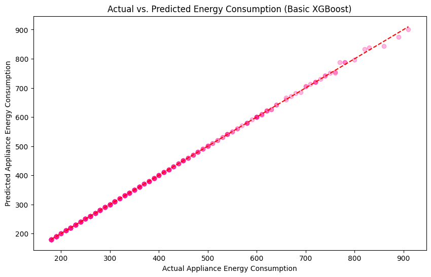

```python
#Evaluate performance
mse_xgb = mean_squared_error(y_test, y_pred_xgb)
rmse_xgb = np.sqrt(mse_xgb)
r2_xgb = r2_score(y_test, y_pred_xgb)

print("Basic XGBoost Performance:")
print("RMSE:", rmse_xgb)
print("R²:", r2_xgb)

#Plot actual vs predicted energy consumption
plt.figure(figsize=(10, 6))
plt.scatter(y_test, y_pred_xgb, alpha=0.3, color='deeppink')
plt.xlabel('Actual Appliance Energy Consumption')
plt.ylabel('Predicted Appliance Energy Consumption')
plt.title('Actual vs. Predicted Energy Consumption (Basic XGBoost)')
plt.plot([y_test.min(), y_test.max()], [y_test.min(), y_test.max()], 'r--')  #Diagonal line
plt.show()
```

```python
#Define a parameter grid for hyperparameter tuning
param_grid_xgb = {
  'n_estimators': [100, 200, 300],
    'max_depth': [3, 5, 7],
    'learning_rate': [0.01, 0.1, 0.2],
    'subsample': [0.7, 0.8 ,1.0],
    'colsample_bytree': [0.7, 0.8, 1.0]
}

#Set up GridSearchCV for hyperparameter tuning
grid_search_xgb = GridSearchCV(estimator=xgb,
                               param_grid=param_grid_xgb,
                               cv=3,
                               scoring='neg_mean_squared_error',
                               n_jobs=-1,
                               verbose=1)

#Fit GridSearchCV on the training data
grid_search_xgb.fit(X_train_scaled, y_train)

#Retrieve the best estimator and parameters
print("Best parameters for XGBoost:", grid_search_xgb.best_params_)
best_xgb = grid_search_xgb.best_estimator_


#Predict on the test set using the best XGBoost model
y_pred_xgb_hpt = best_xgb.predict(X_test_scaled)
```

```
Fitting 3 folds for each of 243 candidates, totalling 729 fits
Best parameters for XGBoost: {'colsample_bytree': 1.0, 'learning_rate': 0.1, 'max_depth': 5, 'n_estimators': 300, 'subsample': 0.7}
```

```
Tuned XGBoost Performance:
RMSE: 0.9005818110966167
R2: 0.9999635219573975
```

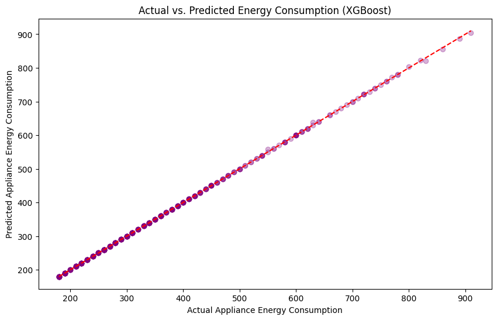

```python
# Calculate evaluation metrics
mse_xgb_hpt = mean_squared_error(y_test, y_pred_xgb_hpt)
rmse_xgb_hpt = np.sqrt(mse_xgb_hpt)
r2_xgb_hpt = r2_score(y_test, y_pred_xgb_hpt)

print("Tuned XGBoost Performance:")
print("RMSE:", rmse_xgb_hpt)
print("R2:", r2_xgb_hpt)

#Plot actual vs predicted energy consumption
plt.figure(figsize=(10, 6))
plt.scatter(y_test, y_pred_xgb_hpt, alpha=0.3, color='purple')
plt.xlabel('Actual Appliance Energy Consumption')
plt.ylabel('Predicted Appliance Energy Consumption')
plt.title('Actual vs. Predicted Energy Consumption (XGBoost)')
plt.plot([y_test.min(), y_test.max()], [y_test.min(), y_test.max()], 'r--')  #Diagonal line
plt.show()
```

# **Gradient Boosting Regressor**

```python
#Initialize the Gradient Boosting Regressor with default parameters
gbr = GradientBoostingRegressor(random_state=42)

#Train the model on your training data
gbr.fit(X_train_scaled, y_train)

#Predict on the test set
y_pred_gbr = gbr.predict(X_test_scaled)
```

```
Basic Gradient Boosting Performance:
RMSE: 1.1258118328948852
R²: 0.9999430124525412
```

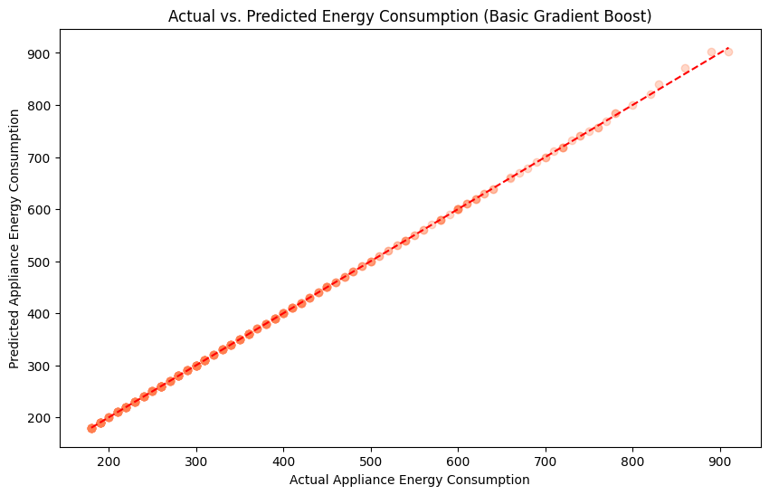

```python
#Evaluate performance
mse_gbr = mean_squared_error(y_test, y_pred_gbr)
rmse_gbr = np.sqrt(mse_gbr)
r2_gbr = r2_score(y_test, y_pred_gbr)

print("Basic Gradient Boosting Performance:")
print("RMSE:", rmse_gbr)
print("R²:", r2_gbr)

#Plot actual vs predicted energy consumption
plt.figure(figsize=(10, 6))
plt.scatter(y_test, y_pred_gbr, alpha=0.3, color='coral')
plt.xlabel('Actual Appliance Energy Consumption')
plt.ylabel('Predicted Appliance Energy Consumption')
plt.title('Actual vs. Predicted Energy Consumption (Basic Gradient Boost)')
plt.plot([y_test.min(), y_test.max()], [y_test.min(), y_test.max()], 'r--')  #Diagonal line
plt.show()
```

```python
#Define the parameter grid for hyperparameter tuning
param_grid_gbr = {
    'n_estimators': [100, 200, 300],
    'max_depth': [3, 5, 7],
    'learning_rate': [0.01, 0.1, 0.2],
    'min_samples_split': [2, 5, 10],
    'min_samples_leaf': [1, 2, 4]
}

#Setup GridSearchCV
grid_search_gbr = GridSearchCV(estimator=gbr,
                               param_grid=param_grid_gbr,
                               cv=3,
                               scoring='neg_mean_squared_error',
                               n_jobs=-1,
                               verbose=1)

#Fit GridSearchCV to the training data
grid_search_gbr.fit(X_train_scaled, y_train)

#Retrieve the best estimator and parameters
print("Best parameters for Gradient Boosting:", grid_search_gbr.best_params_)
best_gbr = grid_search_gbr.best_estimator_

#Predict using the best estimator
y_pred_gbr_hpt = best_gbr.predict(X_test_scaled)
```

```
Fitting 3 folds for each of 243 candidates, totalling 729 fits
Best parameters for Gradient Boosting: {'learning_rate': 0.1, 'max_depth': 7, 'min_samples_leaf': 1, 'min_samples_split': 10, 'n_estimators': 300}
```

```
Tuned Gradient Boosting Performance:
RMSE: 0.9669177847173717
R²: 0.999957963413224
```

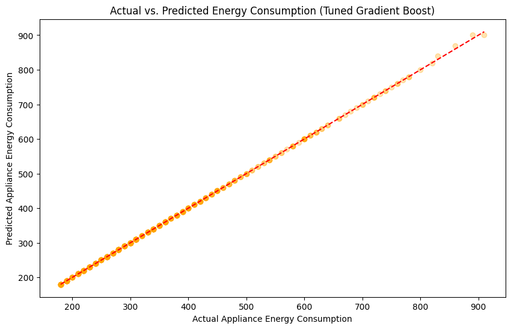

```python
#Evaluate performance of the tuned model
mse_gbr_hpt = mean_squared_error(y_test, y_pred_gbr_hpt)
rmse_gbr_hpt = np.sqrt(mse_gbr_hpt)
r2_gbr_hpt = r2_score(y_test, y_pred_gbr_hpt)

print("\nTuned Gradient Boosting Performance:")
print("RMSE:", rmse_gbr_hpt)
print("R²:", r2_gbr_hpt)

#Plot actual vs predicted energy consumption
plt.figure(figsize=(10, 6))
plt.scatter(y_test, y_pred_gbr_hpt, alpha=0.3, color='Orange')
plt.xlabel('Actual Appliance Energy Consumption')
plt.ylabel('Predicted Appliance Energy Consumption')
plt.title('Actual vs. Predicted Energy Consumption (Tuned Gradient Boost)')
plt.plot([y_test.min(), y_test.max()], [y_test.min(), y_test.max()], 'r--')  #Diagonal line
plt.show()
```

# **Stacking models**

Stacking combines predictions from multiple models (base model) by training a meta model on their output

```python
#Staking the models using their best parameters
base_model = [
    ('rf', RandomForestRegressor(**grid_search_rf.best_params_,
                                 random_state=42)),
    ('xgb', XGBRegressor(**grid_search_xgb.best_params_,
                             random_state=42)),
    ('gbr', GradientBoostingRegressor(**grid_search_gbr.best_params_,
                                      random_state=42))
]

meta_model = LinearRegression()

stacking_model = StackingRegressor(estimators=base_model, final_estimator=meta_model)
stacking_model.fit(X_train_scaled, y_train)

# Predict on the test set
y_pred_stacking = stacking_model.predict(X_test_scaled)
```

```
Stacking model Performance:
RMSE: 1.79039052325956
R²: 0.9998558734835954
```

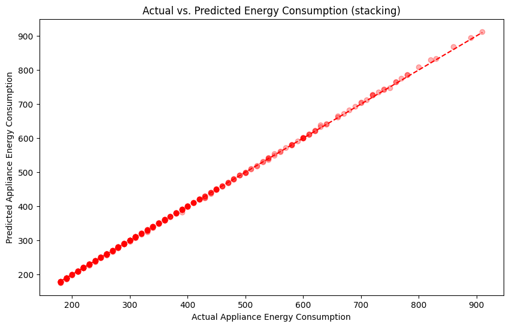

```python
#Evaluate performance
mse_stacking = mean_squared_error(y_test, y_pred_stacking)
rmse_stacking = np.sqrt(mse_stacking)
r2_stacking = r2_score(y_test, y_pred_stacking)

print("Stacking model Performance:")
print("RMSE:", rmse_stacking)
print("R²:", r2_stacking)

#Plot actual vs predicted energy consumption
plt.figure(figsize=(10, 6))
plt.scatter(y_test, y_pred_stacking, alpha=0.3, color='red')
plt.xlabel('Actual Appliance Energy Consumption')
plt.ylabel('Predicted Appliance Energy Consumption')
plt.title('Actual vs. Predicted Energy Consumption (stacking)')
plt.plot([y_test.min(), y_test.max()], [y_test.min(), y_test.max()], 'r--')  #Diagonal line
plt.show()
```

# **Metrics Comparison:**

**RMSE (Root Mean Squared Error)**: Lower values indicate better model performance.

**R² (Coefficient of Determination)**: Values closer to 1 indicate that the model explains most of the variance in the target.

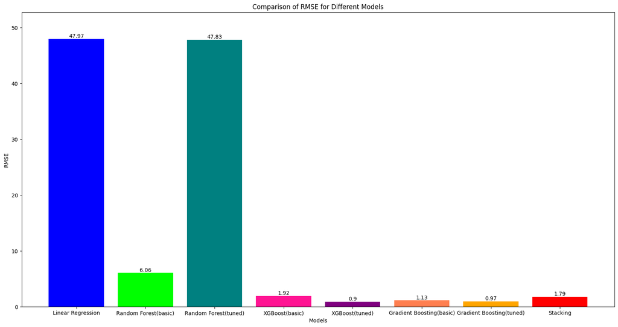

```
Best RMSE: XGBoost(tuned)
```

```python
#Compare the RMSE of the models. the lower the better
rmse_values = {
    'Linear Regression': rmse_lr,
    'Random Forest(basic)': rmse_rf,
    'Random Forest(tuned)': rmse_rf_hpt,
    'XGBoost(basic)': rmse_xgb,
    'XGBoost(tuned)': rmse_xgb_hpt,
    'Gradient Boosting(basic)': rmse_gbr,
    'Gradient Boosting(tuned)': rmse_gbr_hpt,
    'Stacking': rmse_stacking
}

models = list(rmse_values.keys())
rmse = list(rmse_values.values())

plt.figure(figsize=(20, 10))
plt.bar(models, rmse, color=['blue', 'lime' ,'teal', 'deeppink','purple', 'coral','Orange', 'red'])
plt.xlabel("Models")
plt.ylabel("RMSE")
plt.title("Comparison of RMSE for Different Models")
plt.ylim(0, max(rmse) * 1.1)

for i, v in enumerate(rmse):
    plt.text(i, v + 0.01, str(round(v, 2)), ha='center', va='bottom')

plt.show()

print("Best RMSE: " + min(rmse_values, key=rmse_values.get))
```

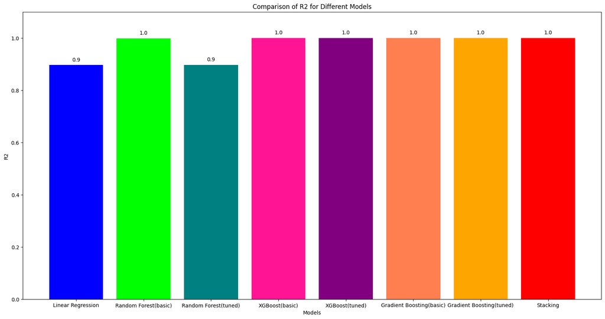

```
Best R2: XGBoost(tuned)
```

```python
#Compare the R2 of the models. the higher the better
r2_values = {
    'Linear Regression': r2_lr,
    'Random Forest(basic)': r2_rf,
    'Random Forest(tuned)': r2_rf_hpt,
    'XGBoost(basic)': r2_xgb,
    'XGBoost(tuned)': r2_xgb_hpt,
    'Gradient Boosting(basic)': r2_gbr,
    'Gradient Boosting(tuned)': r2_gbr_hpt,
    'Stacking': r2_stacking
}

models = list(r2_values.keys())
r2 = list(r2_values.values())

plt.figure(figsize=(20, 10))
plt.bar(models, r2, color=['blue', 'lime' ,'teal', 'deeppink','purple', 'coral','Orange', 'red'])
plt.xlabel("Models")
plt.ylabel("R2")
plt.title("Comparison of R2 for Different Models")
plt.ylim(0, max(r2) * 1.1)

for i, v in enumerate(r2):
    plt.text(i, v + 0.01, str(round(v, 2)), ha='center', va='bottom')

plt.show()

print("Best R2: " + max(r2_values, key=r2_values.get))
```

# **Residual Analysis**

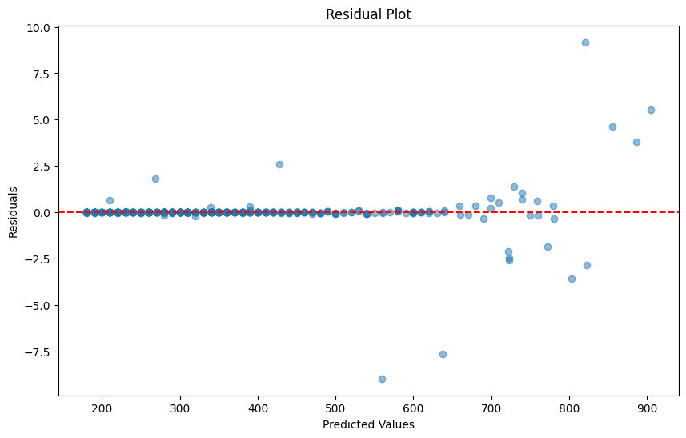

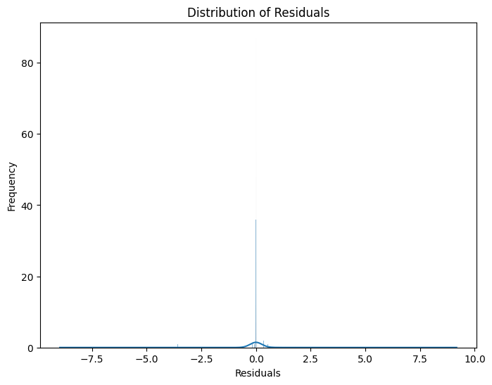

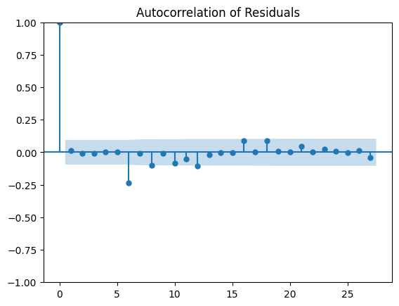

```python
#Residuals analysis for the best model.
residuals = y_test - y_pred_xgb_hpt
# Plot the residuals
plt.figure(figsize=(10, 6))
plt.scatter(y_pred_xgb_hpt, residuals, alpha=0.5)
plt.axhline(y=0, color='r', linestyle='--')  # Add a horizontal line at y=0
plt.xlabel("Predicted Values")
plt.ylabel("Residuals")
plt.title("Residual Plot")
plt.show()

# Analyze the distribution of residuals
plt.figure(figsize=(8, 6))
sns.histplot(residuals, kde=True)
plt.xlabel("Residuals")
plt.ylabel("Frequency")
plt.title("Distribution of Residuals")
plt.show()

# Check for patterns in residuals
plot_acf(residuals)
plt.title("Autocorrelation of Residuals")
plt.show()
```

# **Save and Export model**

```python
#Save the model to a file
joblib.dump(best_xgb, 'best_xgb_model.pkl')

# Optionally, download the file to your local machine
files.download('best_xgb_model.pkl')
```

# **CONCLUSION AND RECOMMENDATION**

Based on the model's prediction and best practices in energy management, here are some key recommendations:

1. **Smart Appliance Usage**
   - Use energy-efficient appliances
   - Schedule high-energy consumption appliances (e.g., washing machine, dishwashers) during off-peak hours to take advantage of lower electricity rates.
2. **Improve Insulation and Climate Control**
   - Optimize home insulation to reduce cooling and heating energy demands
   - Use smart thermostats that adjust settings based on real-time occupancy and weather conditions.
3. **Real-time Monitoring & AI-driven insights**
   - Utilize smart meters and AI-based analytics to get real-time consumption feedback
   - Encourage customers to track and adjust their energy habits based on data-driven insights.

**Recommendations for Power Grid Management:**

1. **Demand Response Optimization**
   - Implement dynamic pricing models to incentivize customer to shift energy-intensive activities to off-peak hours, reducing strain on the grid.
   - Deploy real-time energy monitoring systems to predict peak demand periods and adjust supply accordingly.
2. **Load Balance and Predictive Grid Management**
   - Utilize the developed machine learning model to forecast high-load periods based on weather, historical usage patterns, and real time data.
   - Implement smart load balancing to dynamically allocate power based on predicted demand fluctuations.
3. **Renewable Energy Integration**
   - Promote the use of distributed energy resources (DERs) such as solar and wind power by integrating smart grid technology that adjusts energy flow based on production levels.
   - Implement battery energy storage systems to store excess renewable energy for use during peak demand periods.
4. **Infrastructure Resilience and Stability**
   - Upgrade the grid infrastructure to support bidirectional energy flows, allowing households with solar panels to feed energy back into the grid.
   - Use fault detection algorithms and predictive maintenance to prevent outages and optimize maintenance schedules.

These recommendations can improve **energy cost**, **energy optimization**, and **grid management to a more resilient and sustainable energy system**.